# Ibbotson–Sinquefield scenarios

```julia
# Defaults for running the cells outside Quarto. Under `quarto render` the front-matter
# `params` (overridden by `-P name:value`, see render_reports.sh) are already defined as
# constants, so these assignments are skipped.
@isdefined(spec) || (spec = "ar1935-2025_boot1935-2025_erp4.0")  # directory in specs/
@isdefined(T) || (T = 100)                      # simulated years
@isdefined(horizons) || (horizons = [1, 5, 10, 20, 30, 50, 100])  # horizon table years, ≤ T
@isdefined(n_scen) || (n_scen = 10000)
@isdefined(seed) || (seed = 1234)
```

```julia
import Pkg
Pkg.activate(joinpath(@__DIR__, "..", ".."); io = devnull)

using MacroFinanceScenarios
using MacroFinanceScenarios.IbbotsonSinquefield
using MacroFinanceScenarios.EDA
using MacroFinanceScenarios.ScenariosEvaluation
using CSV, DataFrames, LinearAlgebra, Random, Statistics, StatsBase
using Plots

show_table(t; title = "", digits = 2) =
    display(HTML(sprint(io -> print_table(io, t; backend = :html, digits, title))))

# Everything loaded and computed is in decimal log units; the report shows percent. Means,
# std and percentiles scale by 100; skewness, kurtosis, autocorrelations and correlations
# do not, and `neg` (share of negative values) is already in percent.
pct(sc::Scenarios) = Scenarios(100 .* sc.data, sc.names, sc.start_year)
function pct(df::DataFrame; cols)
    out = copy(df)
    for c in cols
        out[!, c] = 100 .* out[!, c]
    end
    return out
end
moment_cols = [:mean, :std, :min, :p25, :p50, :p75, :max]   # describe_series columns in %
span(p) = "$(p[1])–$(p[2])"
```

## Specification

```julia
spec_dir = joinpath(@__DIR__, "specs", spec)
p = load_issm_params(joinpath(spec_dir, "params.yaml"))
boot_years, U, u_names = load_residuals(joinpath(spec_dir, "bootstrap_residuals.csv"))
u_names == p.names || error("bootstrap residual columns $u_names do not match the state $(p.names)")
hist_moments = CSV.read(joinpath(spec_dir, "hist_moments.csv"), DataFrame; stringtype = String)
hist_cor = CSV.read(joinpath(spec_dir, "hist_correlations.csv"), DataFrame; stringtype = String)
hist_pct = pct(hist_moments; cols = moment_cols)

show_table(DataFrame(parameter = ["AR(1) window", "bootstrap window", "erp_target (%)",
                                  "simulated years", "scenarios", "seed", "last observation"],
                     value = [span(p.ar_period), span(p.boot_period), string(100p.erp_target),
                              string(T), string(n_scen), string(seed), string(p.last_year)]);
           title = "Parameters")
```

| Parameters parameter String | Parameters value String |
| --- | --- |
| AR(1) window | 1935–2025 |
| bootstrap window | 1935–2025 |
| erp_target (%) | 5.5 |
| simulated years | 100 |
| scenarios | 10000 |
| seed | 1234 |
| last observation | 2025 |

Units: returns, rates and moments below are annual log values in percent, except where a table or chart says *simple rate* (`exp(·) − 1` of the log rate, in percent) or *wealth* (of 1 invested); φ, R², skewness, excess kurtosis, autocorrelations and correlations are unit-free.

### AR(1) fits (1935–2025)

```julia
ar_table = DataFrame([(variable = a.variable, n = a.n, c = 100a.c, se_c = 100a.se_c,
                       φ = a.phi, se_φ = a.se_phi, t_φ = a.phi / a.se_phi, σ = 100a.sigma,
                       R² = a.r2, uncond_mean = 100a.c / (1 - a.phi),
                       uncond_std = 100a.sigma / sqrt(1 - a.phi^2))
                      for a in p.model_params if a.variable != "erp"])
show_table(ar_table; title = "AR(1) coefficients, $(span(p.ar_period))")
```

| AR(1) coefficients, 1935–2025 variable String | AR(1) coefficients, 1935–2025 n Int64 | AR(1) coefficients, 1935–2025 c Float64 | AR(1) coefficients, 1935–2025 se_c Float64 | AR(1) coefficients, 1935–2025 φ Float64 | AR(1) coefficients, 1935–2025 se_φ Float64 | AR(1) coefficients, 1935–2025 t_φ Float64 | AR(1) coefficients, 1935–2025 σ Float64 | AR(1) coefficients, 1935–2025 R² Float64 | AR(1) coefficients, 1935–2025 uncond_mean Float64 | AR(1) coefficients, 1935–2025 uncond_std Float64 |
| --- | --- | --- | --- | --- | --- | --- | --- | --- | --- | --- |
| π | 90.0 | 3.5 | 0.0 | 0.0 | 0.0 | NaN | 0.0 | 0.0 | 3.5 | 0.0 |
| r | 90.0 | 0.0 | 0.0 | 0.0 | 0.0 | NaN | 0.0 | 0.3 | 0.0 | 0.0 |
| tp | 90.0 | 1.1 | 0.0 | 0.0 | 0.0 | NaN | 0.0 | 0.0 | 1.1 | 0.0 |

## Simulation

The state `y = [π, r, tp, erp]` follows `y_t = c + A y_{t-1} + u_t` with a diagonal `A` (AR(1) for π, r and tp; erp i.i.d. around `erp_target`). Each simulated year draws one historical year of the demeaned residuals `U` and uses the whole row. Paths start from the last observed year.

```julia
c, A, vnames = p.c, p.A, p.names
sc = simulate_var_bootstrapped_res(c, A, vnames, U, T, n_scen;
                                   y0 = p.y0, start_year = p.start_year, rng = MersenneTwister(seed))
nom = returns_from_components(sc)
rl = returns_from_components(sc; real = true)
μ = unconditional_mean(c, A)

# All simulated series in one Scenarios; rl's :r is sc's :r.
full = Scenarios(vcat(sc.data, nom.data, rl.data[2:3, :, :]),
                 [vnames; nom.names; rl.names[2:3]], sc.start_year)
μπ, μr, μtp, μerp = μ
μ_full = Dict(:π => μπ, :r => μr, :tp => μtp, :erp => μerp,
              :rf => μπ + μr, :rb => μπ + μr + μtp, :re => μπ + μr + μerp,
              :rb_real => μr + μtp, :re_real => μr + μerp)
pick(s::Scenarios, vars) = Scenarios(s.data[indexin(vars, s.names), :, :], vars, s.start_year)

show_table(DataFrame(variable = String.(vnames), c = 100c, φ = diag(A), y0 = 100p.y0,
                     uncond_mean = 100μ);
           title = "VAR(1) intercepts, lags and starting point")
println("Bootstrap residuals: $(size(U, 1)) years, $(first(boot_years))–$(last(boot_years)); ",
        "simulated years $(first(scenario_years(sc)))–$(last(scenario_years(sc))).")
```

```
Bootstrap residuals: 90 years, 1936–2025; simulated years 2026–2125.
```

| VAR(1) intercepts, lags and starting point variable String | VAR(1) intercepts, lags and starting point c Float64 | VAR(1) intercepts, lags and starting point φ Float64 | VAR(1) intercepts, lags and starting point y0 Float64 | VAR(1) intercepts, lags and starting point uncond_mean Float64 |
| --- | --- | --- | --- | --- |
| π | 3.5 | 0.0 | 2.64 | 3.5 |
| r | 0.0 | 0.0 | 1.54 | 0.0 |
| tp | 1.1 | 0.0 | 1.88 | 1.1 |
| erp | 5.5 | 0.0 | 8.71 | 5.5 |

## Fan charts

5–95 and 25–75 percentile bands, median, and the unconditional mean of the VAR (dashed), mapped to each series (e.g. `re`: `μ_π + μ_r + erp_target`; real returns without `μ_π`).

```julia
fans(vars; kwargs...) = [v === nothing ? plot(; framestyle = :none) :
                         fan(full, v; μ = μ_full[v], kwargs...) for v in vars]
```

```
fans (generic function with 1 method)
```

### Cumulative wealth

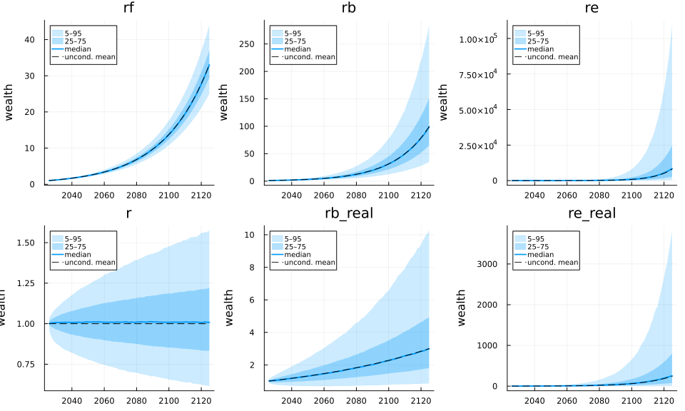

Wealth of 1 invested, nominal (top) and real (bottom)

```julia
plot(fans([:rf, :rb, :re, :r, :rb_real, :re_real]; kind = :wealth)...;
     layout = (2, 3), size = (1000, 600), ylabel = "wealth")
```

### Annualised returns

Geometric-average annual return (annual inflation rate for π) over the first `h` years, `exp(sum(x_1..h)/h) − 1`.

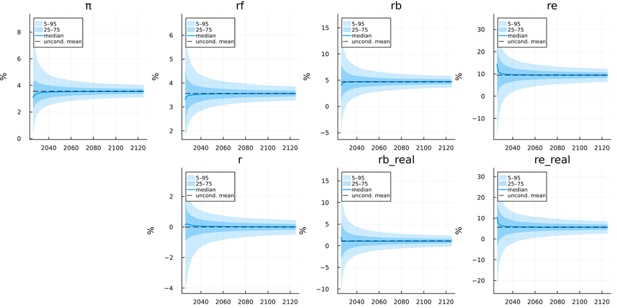

Annualised simple rates: inflation and nominal returns (top), real returns (bottom)

```julia
plot(fans([:π, :rf, :rb, :re, nothing, :r, :rb_real, :re_real]; kind = :annualised,
          simple = true, scale = 100)...;
     layout = (2, 4), size = (1200, 600), ylabel = "%")
```

### Yearly levels

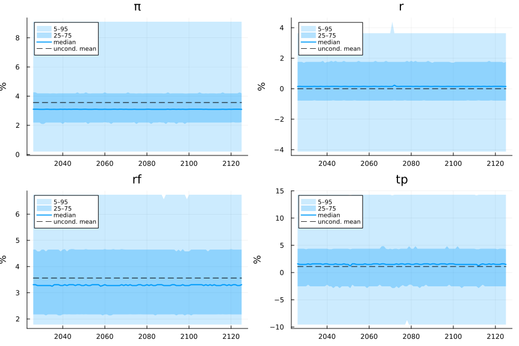

Simulated yearly levels of inflation, the real and nominal short rate and the term premium, simple rates

```julia
plot(fans([:π, :r, :rf, :tp]; kind = :level, simple = true, scale = 100)...;
     layout = (2, 2), size = (900, 600), ylabel = "%")
```

## Evaluation

### Per-path moments

Statistics computed within each simulated path, then summarised across scenarios; the `historical` column is the bootstrap sample (`erp` differs by design: its simulated mean is `erp_target`). `neg` is the percent of years with a negative value.

```julia
for (label, s) in (("components", sc), ("nominal returns", nom), ("real returns", rl))
    for (name, t) in path_moments(pct(s); hist = hist_pct)
        show_table(t; title = "$name ($label)")
    end
end
```

| π (components) statistic String | π (components) historical Float64 | π (components) mean Float64 | π (components) p5 Float64 | π (components) p25 Float64 | π (components) p50 Float64 | π (components) p75 Float64 | π (components) p95 Float64 |
| --- | --- | --- | --- | --- | --- | --- | --- |
| mean | 3.5 | 3.5 | 3.08 | 3.32 | 3.49 | 3.67 | 3.95 |
| std | 3.13 | 2.63 | 1.99 | 2.34 | 2.61 | 2.91 | 3.33 |
| skewness | 1.55 | 1.69 | 0.5 | 1.07 | 1.85 | 2.22 | 2.69 |
| ex_kurtosis | 3.42 | 6.01 | 1.19 | 2.54 | 6.24 | 8.39 | 11.71 |
| ar1 | 0.53 | -0.01 | -0.16 | -0.07 | -0.01 | 0.05 | 0.15 |
| neg | 3.3 | 4.48 | 1.0 | 3.0 | 4.0 | 6.0 | 8.0 |

| r (components) statistic String | r (components) historical Float64 | r (components) mean Float64 | r (components) p5 Float64 | r (components) p25 Float64 | r (components) p50 Float64 | r (components) p75 Float64 | r (components) p95 Float64 |
| --- | --- | --- | --- | --- | --- | --- | --- |
| mean | -0.14 | 0.0 | -0.49 | -0.18 | 0.01 | 0.2 | 0.46 |
| std | 3.46 | 2.84 | 2.12 | 2.52 | 2.82 | 3.15 | 3.62 |
| skewness | -1.5 | -1.7 | -2.68 | -2.26 | -1.91 | -1.06 | -0.34 |
| ex_kurtosis | 4.56 | 6.44 | 0.98 | 2.83 | 6.9 | 9.08 | 12.24 |
| ar1 | 0.55 | -0.01 | -0.16 | -0.07 | -0.01 | 0.05 | 0.15 |
| neg | 41.76 | 43.27 | 35.0 | 40.0 | 43.0 | 47.0 | 51.0 |

| tp (components) statistic String | tp (components) historical Float64 | tp (components) mean Float64 | tp (components) p5 Float64 | tp (components) p25 Float64 | tp (components) p50 Float64 | tp (components) p75 Float64 | tp (components) p95 Float64 |
| --- | --- | --- | --- | --- | --- | --- | --- |
| mean | 1.14 | 1.1 | 0.04 | 0.66 | 1.09 | 1.52 | 2.16 |
| std | 6.38 | 6.33 | 5.52 | 6.0 | 6.33 | 6.66 | 7.15 |
| skewness | 0.01 | 0.01 | -0.37 | -0.14 | 0.01 | 0.17 | 0.39 |
| ex_kurtosis | 0.32 | 0.32 | -0.26 | 0.04 | 0.29 | 0.55 | 1.02 |
| ar1 | -0.06 | -0.01 | -0.17 | -0.08 | -0.01 | 0.06 | 0.15 |
| neg | 40.66 | 40.07 | 32.0 | 37.0 | 40.0 | 43.0 | 48.0 |

| erp (components) statistic String | erp (components) historical Float64 | erp (components) mean Float64 | erp (components) p5 Float64 | erp (components) p25 Float64 | erp (components) p50 Float64 | erp (components) p75 Float64 | erp (components) p95 Float64 |
| --- | --- | --- | --- | --- | --- | --- | --- |
| mean | 5.85 | 5.5 | 2.74 | 4.43 | 5.53 | 6.63 | 8.13 |
| std | 16.64 | 16.26 | 13.93 | 15.26 | 16.24 | 17.25 | 18.69 |
| skewness | -0.95 | -0.96 | -1.4 | -1.14 | -0.97 | -0.78 | -0.52 |
| ex_kurtosis | 1.1 | 0.99 | -0.36 | 0.35 | 0.94 | 1.54 | 2.51 |
| ar1 | -0.03 | -0.01 | -0.17 | -0.08 | -0.01 | 0.05 | 0.15 |
| neg | 27.47 | 27.77 | 21.0 | 25.0 | 28.0 | 31.0 | 35.0 |

| rf (nominal returns) statistic String | rf (nominal returns) historical Float64 | rf (nominal returns) mean Float64 | rf (nominal returns) p5 Float64 | rf (nominal returns) p25 Float64 | rf (nominal returns) p50 Float64 | rf (nominal returns) p75 Float64 | rf (nominal returns) p95 Float64 |
| --- | --- | --- | --- | --- | --- | --- | --- |
| mean | 3.36 | 3.5 | 3.23 | 3.39 | 3.5 | 3.61 | 3.79 |
| std | 2.98 | 1.69 | 1.4 | 1.56 | 1.68 | 1.81 | 1.98 |
| skewness | 0.96 | 1.12 | 0.5 | 0.89 | 1.15 | 1.37 | 1.64 |
| ex_kurtosis | 1.01 | 1.91 | -0.21 | 0.96 | 1.94 | 2.77 | 4.07 |
| ar1 | 0.89 | -0.01 | -0.17 | -0.08 | -0.01 | 0.06 | 0.16 |
| neg | 0.0 | 0.0 | 0.0 | 0.0 | 0.0 | 0.0 | 0.0 |

| rb (nominal returns) statistic String | rb (nominal returns) historical Float64 | rb (nominal returns) mean Float64 | rb (nominal returns) p5 Float64 | rb (nominal returns) p25 Float64 | rb (nominal returns) p50 Float64 | rb (nominal returns) p75 Float64 | rb (nominal returns) p95 Float64 |
| --- | --- | --- | --- | --- | --- | --- | --- |
| mean | 4.5 | 4.6 | 3.57 | 4.18 | 4.59 | 5.02 | 5.65 |
| std | 6.92 | 6.26 | 5.39 | 5.9 | 6.27 | 6.61 | 7.14 |
| skewness | 0.58 | 0.25 | -0.24 | 0.05 | 0.25 | 0.46 | 0.72 |
| ex_kurtosis | 1.47 | 0.77 | -0.03 | 0.38 | 0.73 | 1.1 | 1.7 |
| ar1 | 0.03 | -0.01 | -0.17 | -0.08 | -0.01 | 0.06 | 0.15 |
| neg | 18.68 | 17.76 | 12.0 | 15.0 | 18.0 | 20.0 | 24.0 |

| re (nominal returns) statistic String | re (nominal returns) historical Float64 | re (nominal returns) mean Float64 | re (nominal returns) p5 Float64 | re (nominal returns) p25 Float64 | re (nominal returns) p50 Float64 | re (nominal returns) p75 Float64 | re (nominal returns) p95 Float64 |
| --- | --- | --- | --- | --- | --- | --- | --- |
| mean | 10.56 | 9.0 | 6.27 | 7.93 | 9.04 | 10.12 | 11.61 |
| std | 16.37 | 16.07 | 13.68 | 15.03 | 16.04 | 17.07 | 18.59 |
| skewness | -1.04 | -1.03 | -1.48 | -1.22 | -1.04 | -0.84 | -0.55 |
| ex_kurtosis | 1.31 | 1.19 | -0.32 | 0.46 | 1.17 | 1.82 | 2.89 |
| ar1 | -0.05 | -0.01 | -0.17 | -0.08 | -0.01 | 0.05 | 0.15 |
| neg | 21.98 | 25.56 | 19.0 | 23.0 | 25.0 | 28.0 | 33.0 |

| r (real returns) statistic String | r (real returns) historical Float64 | r (real returns) mean Float64 | r (real returns) p5 Float64 | r (real returns) p25 Float64 | r (real returns) p50 Float64 | r (real returns) p75 Float64 | r (real returns) p95 Float64 |
| --- | --- | --- | --- | --- | --- | --- | --- |
| mean | -0.14 | 0.0 | -0.49 | -0.18 | 0.01 | 0.2 | 0.46 |
| std | 3.46 | 2.84 | 2.12 | 2.52 | 2.82 | 3.15 | 3.62 |
| skewness | -1.5 | -1.7 | -2.68 | -2.26 | -1.91 | -1.06 | -0.34 |
| ex_kurtosis | 4.56 | 6.44 | 0.98 | 2.83 | 6.9 | 9.08 | 12.24 |
| ar1 | 0.55 | -0.01 | -0.16 | -0.07 | -0.01 | 0.05 | 0.15 |
| neg | 41.76 | 43.27 | 35.0 | 40.0 | 43.0 | 47.0 | 51.0 |

| rb_real (real returns) statistic String | rb_real (real returns) historical Float64 | rb_real (real returns) mean Float64 | rb_real (real returns) p5 Float64 | rb_real (real returns) p25 Float64 | rb_real (real returns) p50 Float64 | rb_real (real returns) p75 Float64 | rb_real (real returns) p95 Float64 |
| --- | --- | --- | --- | --- | --- | --- | --- |
| mean | 1.0 | 1.1 | -0.14 | 0.6 | 1.1 | 1.6 | 2.33 |
| std | 8.03 | 7.44 | 6.55 | 7.07 | 7.44 | 7.81 | 8.35 |
| skewness | 0.11 | 0.01 | -0.36 | -0.14 | 0.01 | 0.15 | 0.35 |
| ex_kurtosis | 0.56 | 0.11 | -0.43 | -0.15 | 0.09 | 0.33 | 0.74 |
| ar1 | 0.1 | -0.01 | -0.17 | -0.07 | -0.01 | 0.06 | 0.15 |
| neg | 42.86 | 42.28 | 34.0 | 39.0 | 42.0 | 46.0 | 50.0 |

| re_real (real returns) statistic String | re_real (real returns) historical Float64 | re_real (real returns) mean Float64 | re_real (real returns) p5 Float64 | re_real (real returns) p25 Float64 | re_real (real returns) p50 Float64 | re_real (real returns) p75 Float64 | re_real (real returns) p95 Float64 |
| --- | --- | --- | --- | --- | --- | --- | --- |
| mean | 7.06 | 5.5 | 2.62 | 4.38 | 5.53 | 6.68 | 8.25 |
| std | 17.29 | 16.95 | 14.58 | 15.96 | 16.93 | 17.94 | 19.3 |
| skewness | -0.96 | -0.96 | -1.33 | -1.11 | -0.96 | -0.81 | -0.59 |
| ex_kurtosis | 0.83 | 0.74 | -0.28 | 0.26 | 0.68 | 1.15 | 1.98 |
| ar1 | -0.02 | -0.01 | -0.17 | -0.08 | -0.01 | 0.05 | 0.16 |
| neg | 28.57 | 31.1 | 24.0 | 28.0 | 31.0 | 34.0 | 39.0 |

### Correlations

```julia
for (title, vars) in (("Components and nominal short rate", [:π, :r, :tp, :erp, :rf]),
                      ("Nominal returns, inflation and erp", [:rf, :rb, :re, :π, :erp]),
                      ("Real returns and inflation", [:r, :rb_real, :re_real, :π]))
    s = pick(full, vars)
    show_table(mean_path_correlations(s); title = "$title: mean within-path correlations")
    show_table(path_correlations(s; hist = hist_cor); title = "$title: pairs")
end
```

| Components and nominal short rate: mean within-path correlations variable String | Components and nominal short rate: mean within-path correlations π Float64 | Components and nominal short rate: mean within-path correlations r Float64 | Components and nominal short rate: mean within-path correlations tp Float64 | Components and nominal short rate: mean within-path correlations erp Float64 | Components and nominal short rate: mean within-path correlations rf Float64 |
| --- | --- | --- | --- | --- | --- |
| π | 1.0 | -0.8 | -0.33 | -0.27 | 0.2 |
| r | -0.8 | 1.0 | 0.2 | 0.15 | 0.42 |
| tp | -0.33 | 0.2 | 1.0 | 0.02 | -0.17 |
| erp | -0.27 | 0.15 | 0.02 | 1.0 | -0.17 |
| rf | 0.2 | 0.42 | -0.17 | -0.17 | 1.0 |

| Components and nominal short rate: pairs var1 String | Components and nominal short rate: pairs var2 String | Components and nominal short rate: pairs historical Float64 | Components and nominal short rate: pairs mean Float64 | Components and nominal short rate: pairs p5 Float64 | Components and nominal short rate: pairs p25 Float64 | Components and nominal short rate: pairs p50 Float64 | Components and nominal short rate: pairs p75 Float64 | Components and nominal short rate: pairs p95 Float64 | Components and nominal short rate: pairs hist_rank Float64 |
| --- | --- | --- | --- | --- | --- | --- | --- | --- | --- |
| π | r | -0.59 | -0.8 | -0.9 | -0.85 | -0.81 | -0.76 | -0.66 | 0.99 |
| π | tp | -0.34 | -0.33 | -0.45 | -0.38 | -0.33 | -0.27 | -0.21 | 0.44 |
| π | erp | -0.27 | -0.27 | -0.44 | -0.35 | -0.28 | -0.2 | -0.09 | 0.54 |
| π | rf | 0.36 | 0.2 | 0.01 | 0.11 | 0.19 | 0.28 | 0.4 | 0.91 |
| r | tp | 0.27 | 0.2 | 0.06 | 0.14 | 0.2 | 0.25 | 0.34 | 0.79 |
| r | erp | 0.09 | 0.15 | -0.03 | 0.09 | 0.16 | 0.23 | 0.32 | 0.25 |
| r | rf | 0.54 | 0.42 | 0.28 | 0.37 | 0.42 | 0.48 | 0.56 | 0.92 |
| tp | erp | 0.02 | 0.02 | -0.17 | -0.06 | 0.02 | 0.1 | 0.21 | 0.5 |
| tp | rf | -0.04 | -0.17 | -0.36 | -0.25 | -0.18 | -0.09 | 0.04 | 0.85 |
| erp | rf | -0.18 | -0.17 | -0.35 | -0.24 | -0.17 | -0.09 | 0.02 | 0.45 |

| Nominal returns, inflation and erp: mean within-path correlations variable String | Nominal returns, inflation and erp: mean within-path correlations rf Float64 | Nominal returns, inflation and erp: mean within-path correlations rb Float64 | Nominal returns, inflation and erp: mean within-path correlations re Float64 | Nominal returns, inflation and erp: mean within-path correlations π Float64 | Nominal returns, inflation and erp: mean within-path correlations erp Float64 |
| --- | --- | --- | --- | --- | --- |
| rf | 1.0 | 0.1 | -0.06 | 0.2 | -0.17 |
| rb | 0.1 | 1.0 | -0.01 | -0.28 | -0.02 |
| re | -0.06 | -0.01 | 1.0 | -0.26 | 0.99 |
| π | 0.2 | -0.28 | -0.26 | 1.0 | -0.27 |
| erp | -0.17 | -0.02 | 0.99 | -0.27 | 1.0 |

| Nominal returns, inflation and erp: pairs var1 String | Nominal returns, inflation and erp: pairs var2 String | Nominal returns, inflation and erp: pairs historical Float64 | Nominal returns, inflation and erp: pairs mean Float64 | Nominal returns, inflation and erp: pairs p5 Float64 | Nominal returns, inflation and erp: pairs p25 Float64 | Nominal returns, inflation and erp: pairs p50 Float64 | Nominal returns, inflation and erp: pairs p75 Float64 | Nominal returns, inflation and erp: pairs p95 Float64 | Nominal returns, inflation and erp: pairs hist_rank Float64 |
| --- | --- | --- | --- | --- | --- | --- | --- | --- | --- |
| rf | rb | 0.39 | 0.1 | -0.08 | 0.02 | 0.09 | 0.17 | 0.27 | 1.0 |
| rf | re | -0.0 | -0.06 | -0.25 | -0.14 | -0.06 | 0.01 | 0.12 | 0.7 |
| rf | π | 0.36 | 0.2 | 0.01 | 0.11 | 0.19 | 0.28 | 0.4 | 0.91 |
| rf | erp | -0.18 | -0.17 | -0.35 | -0.24 | -0.17 | -0.09 | 0.02 | 0.45 |
| rb | re | 0.01 | -0.01 | -0.2 | -0.09 | -0.01 | 0.07 | 0.17 | 0.59 |
| rb | π | -0.16 | -0.28 | -0.38 | -0.32 | -0.28 | -0.24 | -0.18 | 0.98 |
| rb | erp | -0.06 | -0.02 | -0.2 | -0.1 | -0.02 | 0.05 | 0.15 | 0.38 |
| re | π | -0.21 | -0.26 | -0.43 | -0.34 | -0.26 | -0.19 | -0.07 | 0.69 |
| re | erp | 0.98 | 0.99 | 0.99 | 0.99 | 0.99 | 1.0 | 1.0 | 0.0 |
| π | erp | -0.27 | -0.27 | -0.44 | -0.35 | -0.28 | -0.2 | -0.09 | 0.54 |

| Real returns and inflation: mean within-path correlations variable String | Real returns and inflation: mean within-path correlations r Float64 | Real returns and inflation: mean within-path correlations rb_real Float64 | Real returns and inflation: mean within-path correlations re_real Float64 | Real returns and inflation: mean within-path correlations π Float64 |
| --- | --- | --- | --- | --- |
| r | 1.0 | 0.55 | 0.31 | -0.8 |
| rb_real | 0.55 | 1.0 | 0.17 | -0.59 |
| re_real | 0.31 | 0.17 | 1.0 | -0.4 |
| π | -0.8 | -0.59 | -0.4 | 1.0 |

| Real returns and inflation: pairs var1 String | Real returns and inflation: pairs var2 String | Real returns and inflation: pairs historical Float64 | Real returns and inflation: pairs mean Float64 | Real returns and inflation: pairs p5 Float64 | Real returns and inflation: pairs p25 Float64 | Real returns and inflation: pairs p50 Float64 | Real returns and inflation: pairs p75 Float64 | Real returns and inflation: pairs p95 Float64 | Real returns and inflation: pairs hist_rank Float64 |
| --- | --- | --- | --- | --- | --- | --- | --- | --- | --- |
| r | rb_real | 0.64 | 0.55 | 0.45 | 0.51 | 0.55 | 0.59 | 0.64 | 0.96 |
| r | re_real | 0.28 | 0.31 | 0.13 | 0.25 | 0.32 | 0.39 | 0.48 | 0.37 |
| r | π | -0.59 | -0.8 | -0.9 | -0.85 | -0.81 | -0.76 | -0.66 | 0.99 |
| rb_real | re_real | 0.18 | 0.17 | -0.03 | 0.09 | 0.17 | 0.25 | 0.36 | 0.53 |
| rb_real | π | -0.52 | -0.59 | -0.66 | -0.62 | -0.59 | -0.56 | -0.51 | 0.91 |
| re_real | π | -0.38 | -0.4 | -0.56 | -0.48 | -0.41 | -0.33 | -0.21 | 0.6 |

### Horizon percentiles

Annualised returns: the geometric-average annual return (annual inflation rate for π) over `h` years, `exp(sum(x_1..h)/h) − 1`, in percent.

```julia
function horizon_tables(vars; kind, label)
    for v in vars
        t = select(horizon_percentiles(full; vars = [v], horizons = filter(<=(T), horizons), kind,
                                       probs = [0.0, 0.05, 0.25, 0.5, 0.75, 0.95, 1.0],
                                       simple = true), Not(:variable))
        t = rename(t, :p0 => :min, :p100 => :max)
        t = pct(t; cols = names(t, Not([:horizon, :year])))
        show_table(t; title = "$v, $label")
    end
end
horizon_tables([:π, :rf, :rb, :re, :r, :rb_real, :re_real]; kind = :annualised,
               label = "annualised (simple rate, %)")
```

| π, annualised (simple rate, %) horizon Int64 | π, annualised (simple rate, %) year Int64 | π, annualised (simple rate, %) mean Float64 | π, annualised (simple rate, %) min Float64 | π, annualised (simple rate, %) p5 Float64 | π, annualised (simple rate, %) p25 Float64 | π, annualised (simple rate, %) p50 Float64 | π, annualised (simple rate, %) p75 Float64 | π, annualised (simple rate, %) p95 Float64 | π, annualised (simple rate, %) max Float64 |
| --- | --- | --- | --- | --- | --- | --- | --- | --- | --- |
| 1.0 | 2026.0 | 3.62 | -2.43 | 0.2 | 2.2 | 3.1 | 4.26 | 9.1 | 18.93 |
| 5.0 | 2030.0 | 3.59 | 0.04 | 1.87 | 2.75 | 3.4 | 4.24 | 5.95 | 11.19 |
| 10.0 | 2035.0 | 3.57 | 0.71 | 2.31 | 2.96 | 3.47 | 4.08 | 5.17 | 9.13 |
| 20.0 | 2045.0 | 3.56 | 1.72 | 2.63 | 3.13 | 3.51 | 3.95 | 4.63 | 6.99 |
| 30.0 | 2055.0 | 3.56 | 2.02 | 2.79 | 3.2 | 3.53 | 3.88 | 4.45 | 6.18 |
| 50.0 | 2075.0 | 3.56 | 2.37 | 2.95 | 3.29 | 3.55 | 3.81 | 4.23 | 5.35 |
| 100.0 | 2125.0 | 3.56 | 2.54 | 3.12 | 3.37 | 3.55 | 3.74 | 4.03 | 4.64 |

| rf, annualised (simple rate, %) horizon Int64 | rf, annualised (simple rate, %) year Int64 | rf, annualised (simple rate, %) mean Float64 | rf, annualised (simple rate, %) min Float64 | rf, annualised (simple rate, %) p5 Float64 | rf, annualised (simple rate, %) p25 Float64 | rf, annualised (simple rate, %) p50 Float64 | rf, annualised (simple rate, %) p75 Float64 | rf, annualised (simple rate, %) p95 Float64 | rf, annualised (simple rate, %) max Float64 |
| --- | --- | --- | --- | --- | --- | --- | --- | --- | --- |
| 1.0 | 2026.0 | 3.58 | 0.27 | 1.79 | 2.18 | 3.31 | 4.65 | 6.74 | 10.83 |
| 5.0 | 2030.0 | 3.56 | 1.27 | 2.41 | 3.0 | 3.49 | 4.03 | 4.97 | 8.28 |
| 10.0 | 2035.0 | 3.55 | 1.85 | 2.7 | 3.15 | 3.52 | 3.9 | 4.53 | 5.97 |
| 20.0 | 2045.0 | 3.56 | 2.42 | 2.93 | 3.29 | 3.54 | 3.82 | 4.25 | 5.4 |
| 30.0 | 2055.0 | 3.56 | 2.58 | 3.05 | 3.34 | 3.55 | 3.77 | 4.11 | 5.06 |
| 50.0 | 2075.0 | 3.56 | 2.81 | 3.17 | 3.39 | 3.55 | 3.73 | 3.99 | 4.5 |
| 100.0 | 2125.0 | 3.56 | 2.91 | 3.28 | 3.44 | 3.56 | 3.68 | 3.86 | 4.3 |

| rb, annualised (simple rate, %) horizon Int64 | rb, annualised (simple rate, %) year Int64 | rb, annualised (simple rate, %) mean Float64 | rb, annualised (simple rate, %) min Float64 | rb, annualised (simple rate, %) p5 Float64 | rb, annualised (simple rate, %) p25 Float64 | rb, annualised (simple rate, %) p50 Float64 | rb, annualised (simple rate, %) p75 Float64 | rb, annualised (simple rate, %) p95 Float64 | rb, annualised (simple rate, %) max Float64 |
| --- | --- | --- | --- | --- | --- | --- | --- | --- | --- |
| 1.0 | 2026.0 | 4.88 | -13.48 | -5.63 | 1.12 | 4.1 | 7.61 | 16.96 | 23.85 |
| 5.0 | 2030.0 | 4.73 | -7.7 | 0.08 | 2.74 | 4.59 | 6.66 | 9.73 | 18.02 |
| 10.0 | 2035.0 | 4.72 | -2.4 | 1.39 | 3.31 | 4.65 | 6.04 | 8.28 | 14.01 |
| 20.0 | 2045.0 | 4.72 | -0.98 | 2.33 | 3.71 | 4.68 | 5.7 | 7.18 | 10.81 |
| 30.0 | 2055.0 | 4.7 | -0.04 | 2.73 | 3.87 | 4.68 | 5.51 | 6.73 | 9.38 |
| 50.0 | 2075.0 | 4.7 | 0.88 | 3.17 | 4.06 | 4.68 | 5.31 | 6.28 | 8.22 |
| 100.0 | 2125.0 | 4.7 | 2.21 | 3.63 | 4.27 | 4.7 | 5.14 | 5.82 | 7.27 |

| re, annualised (simple rate, %) horizon Int64 | re, annualised (simple rate, %) year Int64 | re, annualised (simple rate, %) mean Float64 | re, annualised (simple rate, %) min Float64 | re, annualised (simple rate, %) p5 Float64 | re, annualised (simple rate, %) p25 Float64 | re, annualised (simple rate, %) p50 Float64 | re, annualised (simple rate, %) p75 Float64 | re, annualised (simple rate, %) p95 Float64 | re, annualised (simple rate, %) max Float64 |
| --- | --- | --- | --- | --- | --- | --- | --- | --- | --- |
| 1.0 | 2026.0 | 10.8 | -39.97 | -17.89 | -0.25 | 14.44 | 22.09 | 35.38 | 45.88 |
| 5.0 | 2030.0 | 9.77 | -23.49 | -3.75 | 4.63 | 10.17 | 15.33 | 21.83 | 34.62 |
| 10.0 | 2035.0 | 9.64 | -13.75 | 0.29 | 5.93 | 9.75 | 13.58 | 18.46 | 28.36 |
| 20.0 | 2045.0 | 9.54 | -10.96 | 2.99 | 6.98 | 9.6 | 12.15 | 15.76 | 23.24 |
| 30.0 | 2055.0 | 9.49 | -5.76 | 4.05 | 7.35 | 9.55 | 11.71 | 14.64 | 21.32 |
| 50.0 | 2075.0 | 9.46 | -1.91 | 5.24 | 7.82 | 9.5 | 11.17 | 13.46 | 19.35 |
| 100.0 | 2125.0 | 9.43 | 3.02 | 6.47 | 8.25 | 9.46 | 10.65 | 12.31 | 15.62 |

| r, annualised (simple rate, %) horizon Int64 | r, annualised (simple rate, %) year Int64 | r, annualised (simple rate, %) mean Float64 | r, annualised (simple rate, %) min Float64 | r, annualised (simple rate, %) p5 Float64 | r, annualised (simple rate, %) p25 Float64 | r, annualised (simple rate, %) p50 Float64 | r, annualised (simple rate, %) p75 Float64 | r, annualised (simple rate, %) p95 Float64 | r, annualised (simple rate, %) max Float64 |
| --- | --- | --- | --- | --- | --- | --- | --- | --- | --- |
| 1.0 | 2026.0 | 0.02 | -14.14 | -4.12 | -0.77 | 0.15 | 1.76 | 3.64 | 6.3 |
| 5.0 | 2030.0 | -0.02 | -7.9 | -2.47 | -0.68 | 0.14 | 0.84 | 1.8 | 3.74 |
| 10.0 | 2035.0 | -0.01 | -5.17 | -1.67 | -0.53 | 0.08 | 0.61 | 1.31 | 2.75 |
| 20.0 | 2045.0 | 0.0 | -3.31 | -1.11 | -0.39 | 0.04 | 0.44 | 0.98 | 2.1 |
| 30.0 | 2055.0 | 0.0 | -2.38 | -0.9 | -0.33 | 0.03 | 0.37 | 0.8 | 1.71 |
| 50.0 | 2075.0 | 0.0 | -1.71 | -0.7 | -0.25 | 0.02 | 0.28 | 0.63 | 1.39 |
| 100.0 | 2125.0 | 0.0 | -1.11 | -0.49 | -0.18 | 0.01 | 0.2 | 0.46 | 0.94 |

| rb_real, annualised (simple rate, %) horizon Int64 | rb_real, annualised (simple rate, %) year Int64 | rb_real, annualised (simple rate, %) mean Float64 | rb_real, annualised (simple rate, %) min Float64 | rb_real, annualised (simple rate, %) p5 Float64 | rb_real, annualised (simple rate, %) p25 Float64 | rb_real, annualised (simple rate, %) p50 Float64 | rb_real, annualised (simple rate, %) p75 Float64 | rb_real, annualised (simple rate, %) p95 Float64 | rb_real, annualised (simple rate, %) max Float64 |
| --- | --- | --- | --- | --- | --- | --- | --- | --- | --- |
| 1.0 | 2026.0 | 1.33 | -17.29 | -10.2 | -2.87 | 1.92 | 5.41 | 17.17 | 22.5 |
| 5.0 | 2030.0 | 1.13 | -11.67 | -4.35 | -1.22 | 1.07 | 3.4 | 6.84 | 14.73 |
| 10.0 | 2035.0 | 1.12 | -7.5 | -2.8 | -0.48 | 1.08 | 2.71 | 5.16 | 11.11 |
| 20.0 | 2045.0 | 1.12 | -5.3 | -1.63 | -0.02 | 1.1 | 2.26 | 3.91 | 7.56 |
| 30.0 | 2055.0 | 1.11 | -4.07 | -1.17 | 0.16 | 1.09 | 2.05 | 3.44 | 6.09 |
| 50.0 | 2075.0 | 1.1 | -3.32 | -0.67 | 0.38 | 1.1 | 1.81 | 2.87 | 5.2 |
| 100.0 | 2125.0 | 1.11 | -1.66 | -0.14 | 0.6 | 1.1 | 1.61 | 2.36 | 3.92 |

| re_real, annualised (simple rate, %) horizon Int64 | re_real, annualised (simple rate, %) year Int64 | re_real, annualised (simple rate, %) mean Float64 | re_real, annualised (simple rate, %) min Float64 | re_real, annualised (simple rate, %) p5 Float64 | re_real, annualised (simple rate, %) p25 Float64 | re_real, annualised (simple rate, %) p50 Float64 | re_real, annualised (simple rate, %) p75 Float64 | re_real, annualised (simple rate, %) p95 Float64 | re_real, annualised (simple rate, %) max Float64 |
| --- | --- | --- | --- | --- | --- | --- | --- | --- | --- |
| 1.0 | 2026.0 | 7.12 | -39.86 | -24.52 | -3.71 | 10.52 | 17.97 | 32.49 | 44.85 |
| 5.0 | 2030.0 | 6.0 | -25.41 | -7.69 | 0.68 | 6.35 | 11.7 | 18.28 | 31.46 |
| 10.0 | 2035.0 | 5.88 | -16.76 | -3.57 | 2.1 | 5.98 | 9.85 | 15.02 | 24.11 |
| 20.0 | 2045.0 | 5.78 | -14.17 | -0.81 | 3.18 | 5.86 | 8.46 | 12.25 | 20.07 |
| 30.0 | 2055.0 | 5.73 | -9.0 | 0.28 | 3.57 | 5.78 | 7.99 | 10.98 | 17.48 |
| 50.0 | 2075.0 | 5.7 | -5.07 | 1.48 | 4.02 | 5.71 | 7.44 | 9.83 | 15.33 |
| 100.0 | 2125.0 | 5.67 | -0.75 | 2.66 | 4.48 | 5.68 | 6.91 | 8.6 | 11.73 |

Levels in year `h` (the yearly-level fan chart numbers), simple rates in percent:

```julia
horizon_tables([:π, :rf, :r]; kind = :level, label = "level in year h (simple rate, %)")
```

| π, level in year h (simple rate, %) horizon Int64 | π, level in year h (simple rate, %) year Int64 | π, level in year h (simple rate, %) mean Float64 | π, level in year h (simple rate, %) min Float64 | π, level in year h (simple rate, %) p5 Float64 | π, level in year h (simple rate, %) p25 Float64 | π, level in year h (simple rate, %) p50 Float64 | π, level in year h (simple rate, %) p75 Float64 | π, level in year h (simple rate, %) p95 Float64 | π, level in year h (simple rate, %) max Float64 |
| --- | --- | --- | --- | --- | --- | --- | --- | --- | --- |
| 1.0 | 2026.0 | 3.62 | -2.43 | 0.2 | 2.2 | 3.1 | 4.26 | 9.1 | 18.93 |
| 5.0 | 2030.0 | 3.61 | -2.43 | 0.2 | 2.1 | 3.09 | 4.19 | 9.1 | 18.93 |
| 10.0 | 2035.0 | 3.58 | -2.43 | 0.2 | 2.2 | 3.09 | 4.19 | 9.1 | 18.93 |
| 20.0 | 2045.0 | 3.6 | -2.43 | 0.2 | 2.2 | 3.1 | 4.19 | 9.1 | 18.93 |
| 30.0 | 2055.0 | 3.6 | -2.43 | 0.2 | 2.2 | 3.1 | 4.19 | 9.1 | 18.93 |
| 50.0 | 2075.0 | 3.58 | -2.43 | 0.2 | 2.1 | 3.09 | 4.18 | 9.1 | 18.93 |
| 100.0 | 2125.0 | 3.59 | -2.43 | 0.2 | 2.22 | 3.09 | 4.19 | 9.1 | 18.93 |

| rf, level in year h (simple rate, %) horizon Int64 | rf, level in year h (simple rate, %) year Int64 | rf, level in year h (simple rate, %) mean Float64 | rf, level in year h (simple rate, %) min Float64 | rf, level in year h (simple rate, %) p5 Float64 | rf, level in year h (simple rate, %) p25 Float64 | rf, level in year h (simple rate, %) p50 Float64 | rf, level in year h (simple rate, %) p75 Float64 | rf, level in year h (simple rate, %) p95 Float64 | rf, level in year h (simple rate, %) max Float64 |
| --- | --- | --- | --- | --- | --- | --- | --- | --- | --- |
| 1.0 | 2026.0 | 3.58 | 0.27 | 1.79 | 2.18 | 3.31 | 4.65 | 6.74 | 10.83 |
| 5.0 | 2030.0 | 3.56 | 0.27 | 1.79 | 2.18 | 3.28 | 4.65 | 6.74 | 10.83 |
| 10.0 | 2035.0 | 3.56 | 0.27 | 1.79 | 2.18 | 3.25 | 4.65 | 6.74 | 10.83 |
| 20.0 | 2045.0 | 3.6 | 0.27 | 1.79 | 2.18 | 3.31 | 4.66 | 6.74 | 10.83 |
| 30.0 | 2055.0 | 3.57 | 0.27 | 1.79 | 2.18 | 3.31 | 4.65 | 6.74 | 10.83 |
| 50.0 | 2075.0 | 3.58 | 0.27 | 1.79 | 2.18 | 3.28 | 4.65 | 6.74 | 10.83 |
| 100.0 | 2125.0 | 3.6 | 0.27 | 1.79 | 2.18 | 3.31 | 4.65 | 6.74 | 10.83 |

| r, level in year h (simple rate, %) horizon Int64 | r, level in year h (simple rate, %) year Int64 | r, level in year h (simple rate, %) mean Float64 | r, level in year h (simple rate, %) min Float64 | r, level in year h (simple rate, %) p5 Float64 | r, level in year h (simple rate, %) p25 Float64 | r, level in year h (simple rate, %) p50 Float64 | r, level in year h (simple rate, %) p75 Float64 | r, level in year h (simple rate, %) p95 Float64 | r, level in year h (simple rate, %) max Float64 |
| --- | --- | --- | --- | --- | --- | --- | --- | --- | --- |
| 1.0 | 2026.0 | 0.02 | -14.14 | -4.12 | -0.77 | 0.15 | 1.76 | 3.64 | 6.3 |
| 5.0 | 2030.0 | 0.02 | -14.14 | -4.12 | -0.77 | 0.15 | 1.76 | 3.64 | 6.3 |
| 10.0 | 2035.0 | 0.04 | -14.14 | -4.12 | -0.77 | 0.15 | 1.76 | 3.64 | 6.3 |
| 20.0 | 2045.0 | 0.05 | -14.14 | -4.12 | -0.77 | 0.15 | 1.76 | 3.64 | 6.3 |
| 30.0 | 2055.0 | 0.04 | -14.14 | -4.12 | -0.77 | 0.15 | 1.82 | 3.64 | 6.3 |
| 50.0 | 2075.0 | 0.06 | -14.14 | -4.12 | -0.77 | 0.15 | 1.76 | 3.64 | 6.3 |
| 100.0 | 2125.0 | 0.07 | -14.14 | -4.12 | -0.77 | 0.15 | 1.76 | 3.64 | 6.3 |

### Drawdowns

Maximum drawdown of wealth (in %) and the longest spell below a previous peak (in years), per path over the first `horizon` simulated years (50 by default).

```julia
function dd_table(s; horizon = 50)
    horizon <= size(s.data, 2) || throw(ArgumentError("horizon $horizon exceeds the $(size(s.data, 2)) simulated years"))
    t = drawdown_table(Scenarios(s.data[:, 1:horizon, :], s.names, s.start_year))
    rows = t.statistic .== "max_drawdown"
    num = names(t, Not([:variable, :statistic]))
    t[rows, num] .*= 100
    return t
end
show_table(dd_table(nom); title = "Nominal, first 50 years")
show_table(dd_table(rl); title = "Real, first 50 years")
```

| Nominal, first 50 years variable String | Nominal, first 50 years statistic String | Nominal, first 50 years mean Float64 | Nominal, first 50 years p5 Float64 | Nominal, first 50 years p25 Float64 | Nominal, first 50 years p50 Float64 | Nominal, first 50 years p75 Float64 | Nominal, first 50 years p95 Float64 |
| --- | --- | --- | --- | --- | --- | --- | --- |
| rf | max_drawdown | 0.0 | 0.0 | 0.0 | 0.0 | 0.0 | 0.0 |
| rf | max_dd_length | 0.0 | 0.0 | 0.0 | 0.0 | 0.0 | 0.0 |
| rb | max_drawdown | 11.64 | 5.63 | 6.86 | 11.97 | 13.57 | 20.08 |
| rb | max_dd_length | 4.75 | 2.0 | 3.0 | 4.0 | 6.0 | 10.0 |
| re | max_drawdown | 39.79 | 19.96 | 30.5 | 39.97 | 46.87 | 61.85 |
| re | max_dd_length | 7.48 | 3.0 | 4.0 | 6.0 | 9.0 | 16.0 |

| Real, first 50 years variable String | Real, first 50 years statistic String | Real, first 50 years mean Float64 | Real, first 50 years p5 Float64 | Real, first 50 years p25 Float64 | Real, first 50 years p50 Float64 | Real, first 50 years p75 Float64 | Real, first 50 years p95 Float64 |
| --- | --- | --- | --- | --- | --- | --- | --- |
| r | max_drawdown | 18.74 | 6.63 | 11.71 | 17.2 | 24.11 | 36.13 |
| r | max_dd_length | 29.5 | 9.0 | 18.0 | 28.0 | 42.0 | 50.0 |
| rb_real | max_drawdown | 31.81 | 16.35 | 23.26 | 30.08 | 38.65 | 53.28 |
| rb_real | max_dd_length | 21.58 | 7.0 | 12.0 | 19.0 | 28.0 | 46.0 |
| re_real | max_drawdown | 49.4 | 28.32 | 39.86 | 48.23 | 58.83 | 73.81 |
| re_real | max_dd_length | 12.91 | 4.0 | 7.0 | 11.0 | 16.0 | 29.0 |